# Appendix A

## Overview

Upon cleaning and merging the TIP data, the final merged TIP data file is used to find summary statistics and compare percentages of completion between TIP participants and non TIP participants. The merged file is brought in from the script, “TIP merge and data clean” which produces one final data set for analysis. For more information on the nature of missing data and the merge, consult the prior script.

The merged TIP data file we use for the below figures and analyses has complete variables for 16,012 teachers, 312 of which participate in TIP, and 15700 who did not participate in TIP. Information on these teachers is collected across an 8 year period, from 2010 through 2018.

## Visualization

In order to evaluate the effectiveness of TIP participation on retention, we first look to get a picture of the average length of time spent in the district by teachers, as well as how retention patterns regularly play out in the Philadelphia school district.

How long do TIP and non TIP participants stay in teaching profession, on average? Figure 1 breaks down these differences. TIP participation rates are relatively evenly split among four strata of teacher groups. These strata divide teachers into one of four groups, based on how long each teacher has served in the district.

Figure 2 breaks down the liklihood of retention for teachers based on their strata. The table sorts teachers by strata to compare how groups of teacher strata differ in retention rates.

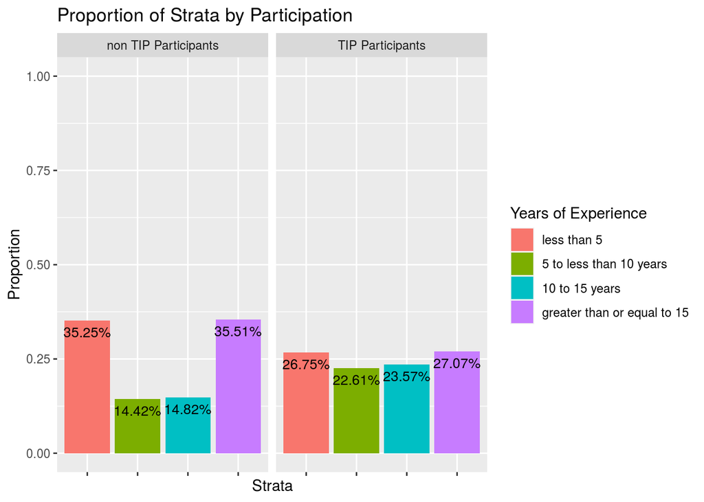

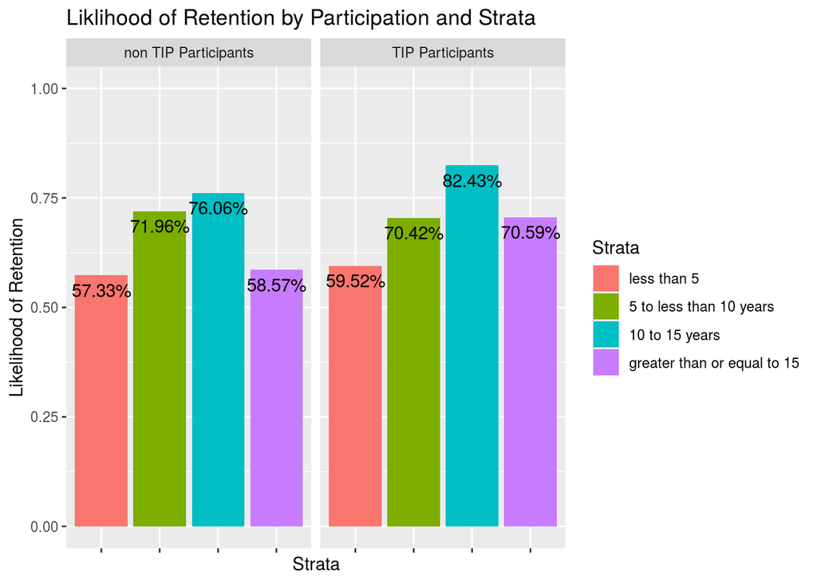

## Constructing a dataset for analysis

In order to continue with a statistical analysis, we create an analysis dataset with a row for each Deidentified ID that has all of its unique variables. Recall that the merged_dataset has multiple rows for the same Deidentified ID. For instance, teacher ID #72 may have changed schools over the time we have the data. Or, teacher ID #72 may have changed their title (example: a Special Education teacher moving to a General Education teacher). In order to capture that change, we can come up with a new variable that records the number of times the teacher changed schools, titles, etc.

Variables that change for each ID, such as gender, or school, will be gathered and then re-coded. For instance, the original data set had a unique entry for each year in the data. Here, that is recoded as “total years in TIP data set”. Or, some teachers changed gender over the time frame. This is recoded as “number of genders”. Or, some teachers changed schools during the time frame. This is recoded as “number of schools”.

These new variables, named “number of titles”, or “numer of schools”, are then merged back with merged_participation, to give us one complete dataset for analysis. Limitations to this approach are discussed later.

In choosing the variables to analyze from the analysis dataset, we must make a choice about which variables to choose. For instance, some teachers have more than 1 role, or more than 1 school worked at. In this example code, I simply choose the first observation that appears for that teacher. Since the information is organized by employee age, this is the youngest age at which the teacher started. We can later choose to organize this information differently if need be.

## Model 1

$$log(r/(1-r)) = \beta_0 + \beta_1{x_1} + \beta_2{x_2} +... \beta_p{x_p}$$
The logistic regression model (above) forms the basis for the following statistical tests. Where r is proability of a teacher being retained or not retained, and each x represents a possible predictor, such as gender or years of service in the district, then the model tests the significance of each regression coefficient in predicting the log odds of retention.

First, we test the model using participation in TIP as the predictor and retention as the outcome variable.

$$log(r/(1-r)) = \beta_0 + \beta_1{x_1}$$

$$\beta_1 = Participation$$

```
##
## Call:
## glm(formula = Retained ~ Participated, family = binomial, data = analysis_data)
##
## Deviance Residuals:
##     Min       1Q   Median       3Q      Max
## -1.5628  -1.4041   0.9665   0.9665   0.9665
##
## Coefficients:
##               Estimate Std. Error z value Pr(>|z|)
## (Intercept)    0.51868    0.01651   31.43  < 2e-16 ***
## Participated1  0.35315    0.12525    2.82  0.00481 **
## ---
## Signif. codes:  0 '***' 0.001 '**' 0.01 '*' 0.05 '.' 0.1 ' ' 1
##
## (Dispersion parameter for binomial family taken to be 1)
##
##     Null deviance: 21121  on 16004  degrees of freedom
## Residual deviance: 21113  on 16003  degrees of freedom
## AIC: 21117
##
## Number of Fisher Scoring iterations: 4
```

|  | x |
| --- | --- |
| (Intercept) | 0.518684 |
| Participated1 | 0.353155 |

## Model 2

$$log(r/(1-r)) = \beta_0 + \beta_1{x_1}$$

```
##
## Call:  glm(formula = Retained ~ Participated + Ethnicity, family = binomial,
##     data = analysis_data)
##
## Coefficients:
##           (Intercept)          Participated1     EthnicityASIAN/PAC
##              0.575070               0.349143              -0.005711
##    EthnicityCAUCASIAN      EthnicityLATINA/O  EthnicityNAT AM/INUIT
##             -0.096267               0.200386              -0.004525
##        EthnicityOTHER  EthnicityPREF NO DISC
##              0.023313               2.057279
##
## Degrees of Freedom: 16004 Total (i.e. Null);  15997 Residual
## Null Deviance:       21120
## Residual Deviance: 21070     AIC: 21090
```

```
##
## Call:
## glm(formula = Retained ~ Participated + Ethnicity, family = binomial,
##     data = analysis_data)
##
## Deviance Residuals:
##     Min       1Q   Median       3Q      Max
## -2.3246  -1.3863   0.9449   0.9820   0.9820
##
## Coefficients:
##                        Estimate Std. Error z value Pr(>|z|)
## (Intercept)            0.575070   0.033244  17.298  < 2e-16 ***
## Participated1          0.349143   0.125413   2.784 0.005370 **
## EthnicityASIAN/PAC    -0.005711   0.113672  -0.050 0.959929
## EthnicityCAUCASIAN    -0.096267   0.038554  -2.497 0.012527 *
## EthnicityLATINA/O      0.200386   0.101680   1.971 0.048751 *
## EthnicityNAT AM/INUIT -0.004525   0.348578  -0.013 0.989642
## EthnicityOTHER         0.023313   0.163919   0.142 0.886904
## EthnicityPREF NO DISC  2.057279   0.597487   3.443 0.000575 ***
## ---
## Signif. codes:  0 '***' 0.001 '**' 0.01 '*' 0.05 '.' 0.1 ' ' 1
##
## (Dispersion parameter for binomial family taken to be 1)
##
##     Null deviance: 21121  on 16004  degrees of freedom
## Residual deviance: 21075  on 15997  degrees of freedom
## AIC: 21091
##
## Number of Fisher Scoring iterations: 4
```

[output not shown]

[output not shown]

# Model 3

Next, we examine the interaction effects of Strata and Participation. While strata itself was a signficant predictor of retention, the interaction between strata and participation in TIP was not significant.

$$log(r/(1-r)) = \beta_0 + \beta_1{x_1} * \beta_2{x_2}$$

$$\beta_1 = Strata$$
$$\beta_2 = Participation$$

```
##
## Call:
## glm(formula = Retained ~ Strata * Participated, family = binomial,
##     data = analysis_data)
##
## Deviance Residuals:
##     Min       1Q   Median       3Q      Max
## -1.9103  -1.0371   0.7851   0.9084   1.3245
##
## Coefficients:
##                                                 Estimate Std. Error z value
## (Intercept)                                      0.67194    0.02308  29.114
## Strata5 to less than 10 years                    0.34691    0.05768   6.014
## Strata10 to 15 years                             0.38121    0.05569   6.845
## Stratagreater than or equal to 15               -1.01141    0.04159 -24.317
## Participated1                                    0.21651    0.16794   1.289
## Strata5 to less than 10 years:Participated1      0.41329    0.38760   1.066
## Strata10 to 15 years:Participated1              -0.13023    0.44246  -0.294
## Stratagreater than or equal to 15:Participated1 -0.06810    0.35428  -0.192
##                                                 Pr(>|z|)
## (Intercept)                                      < 2e-16 ***
## Strata5 to less than 10 years                   1.81e-09 ***
## Strata10 to 15 years                            7.67e-12 ***
## Stratagreater than or equal to 15                < 2e-16 ***
## Participated1                                      0.197
## Strata5 to less than 10 years:Participated1        0.286
## Strata10 to 15 years:Participated1                 0.769
## Stratagreater than or equal to 15:Participated1    0.848
## ---
## Signif. codes:  0 '***' 0.001 '**' 0.01 '*' 0.05 '.' 0.1 ' ' 1
##
## (Dispersion parameter for binomial family taken to be 1)
##
##     Null deviance: 21121  on 16004  degrees of freedom
## Residual deviance: 20207  on 15997  degrees of freedom
## AIC: 20223
##
## Number of Fisher Scoring iterations: 4
```

|  | Estimate | Std. Error | z value | Pr(>\|z\|) |
| --- | --- | --- | --- | --- |
| (Intercept) | 0.6719437 | 0.02308012 | 29.1135265 | 2.420424e-186 |
| Strata5 to less than 10 years | 0.3469110 | 0.05768332 | 6.0140613 | 1.809320e-09 |
| Strata10 to 15 years | 0.3812062 | 0.05569472 | 6.8445668 | 7.670764e-12 |
| Stratagreater than or equal to 15 | -1.0114085 | 0.04159328 | -24.3166338 | 1.307461e-130 |
| Participated1 | 0.2165122 | 0.16794350 | 1.2891968 | 1.973297e-01 |
| Strata5 to less than 10 years:Participated1 | 0.4132917 | 0.38759575 | 1.0662957 | 2.862900e-01 |
| Strata10 to 15 years:Participated1 | -0.1302279 | 0.44246350 | -0.2943245 | 7.685100e-01 |
| Stratagreater than or equal to 15:Participated1 | -0.0681027 | 0.35427696 | -0.1922301 | 8.475620e-01 |

```
##
## Call:
## glm(formula = Retained ~ Strata * Participated + Ethnicity +
##     Gender, family = binomial, data = analysis_data)
##
## Deviance Residuals:
##     Min       1Q   Median       3Q      Max
## -2.3328  -1.0970   0.8003   0.9204   1.4089
##
## Coefficients:
##                                                 Estimate Std. Error z value
## (Intercept)                                      0.85783    0.04164  20.600
## Strata5 to less than 10 years                    0.33447    0.05789   5.778
## Strata10 to 15 years                             0.35593    0.05604   6.351
## Stratagreater than or equal to 15               -1.04989    0.04261 -24.638
## Participated1                                    0.20247    0.16831   1.203
## EthnicityASIAN/PAC                              -0.28392    0.11657  -2.436
## EthnicityCAUCASIAN                              -0.21802    0.04079  -5.345
## EthnicityLATINA/O                               -0.01796    0.10453  -0.172
## EthnicityNAT AM/INUIT                           -0.34314    0.35154  -0.976
## EthnicityOTHER                                  -0.28507    0.16555  -1.722
## EthnicityPREF NO DISC                            1.79508    0.59794   3.002
## GenderM                                         -0.05354    0.03820  -1.402
## Strata5 to less than 10 years:Participated1      0.43137    0.38802   1.112
## Strata10 to 15 years:Participated1              -0.14739    0.44312  -0.333
## Stratagreater than or equal to 15:Participated1 -0.09570    0.35492  -0.270
##                                                 Pr(>|z|)
## (Intercept)                                      < 2e-16 ***
## Strata5 to less than 10 years                   7.58e-09 ***
## Strata10 to 15 years                            2.14e-10 ***
## Stratagreater than or equal to 15                < 2e-16 ***
## Participated1                                    0.22900
## EthnicityASIAN/PAC                               0.01486 *
## EthnicityCAUCASIAN                              9.03e-08 ***
## EthnicityLATINA/O                                0.86355
## EthnicityNAT AM/INUIT                            0.32900
## EthnicityOTHER                                   0.08508 .
## EthnicityPREF NO DISC                            0.00268 **
## GenderM                                          0.16098
## Strata5 to less than 10 years:Participated1      0.26625
## Strata10 to 15 years:Participated1               0.73943
## Stratagreater than or equal to 15:Participated1  0.78743
## ---
## Signif. codes:  0 '***' 0.001 '**' 0.01 '*' 0.05 '.' 0.1 ' ' 1
##
## (Dispersion parameter for binomial family taken to be 1)
##
##     Null deviance: 21121  on 16004  degrees of freedom
## Residual deviance: 20152  on 15990  degrees of freedom
## AIC: 20182
##
## Number of Fisher Scoring iterations: 4
```

|  | Estimate | Std. Error | z value | Pr(>\|z\|) |
| --- | --- | --- | --- | --- |
| (Intercept) | 0.85782864 | 0.04164273 | 20.5997207 | 2.760304e-94 |
| Strata5 to less than 10 years | 0.33446609 | 0.05789018 | 5.7775959 | 7.577553e-09 |
| Strata10 to 15 years | 0.35592856 | 0.05604125 | 6.3511884 | 2.136578e-10 |
| Stratagreater than or equal to 15 | -1.04989427 | 0.04261292 | -24.6379350 | 4.956812e-134 |
| Participated1 | 0.20246728 | 0.16830935 | 1.2029473 | 2.289967e-01 |
| EthnicityASIAN/PAC | -0.28391789 | 0.11656705 | -2.4356617 | 1.486458e-02 |
| EthnicityCAUCASIAN | -0.21801740 | 0.04078763 | -5.3451844 | 9.032505e-08 |
| EthnicityLATINA/O | -0.01796468 | 0.10453213 | -0.1718580 | 8.635492e-01 |
| EthnicityNAT AM/INUIT | -0.34314157 | 0.35153571 | -0.9761215 | 3.290043e-01 |
| EthnicityOTHER | -0.28507028 | 0.16554977 | -1.7219612 | 8.507654e-02 |

[output cut: 5 more lines]

# Discussion/Limitations

The first question of interest is the retention of teachers in SDP (the School District of Philadelphia) who participated or did not particpate in TIP. The analyses show that TIP is a significant predictor of retention for teachers in SDP.

Model 1 shows us that participating in TIP did have a positive effect on teacher retention.

Next steps will be to look more closely at the differences in teacher retention rates betweeen strata and number of years served for TIP teachers. As mentioned in the original proposal, “non-retention of high-performing teachers is a serious problem for urban school districts”. Better understanding the patterns of retention based on strata and years worked can shed light the specific groups that a program like TIP has the most effect on, and better yet, why, such a program impacts retention rates.

A few limitations on the current analysis exist. First, the sample size of TIP teachers is a fraction of the sample size of non_TIP teachers. Such sample size differences may result in complications for future interaction analyses or causal interpretations. Additionally, teacher retention is calculated as a teacher staying in the school district dataset from one year to another. This fails to capture differencees in changed Titles of teachers, or where specifically teachers move throughout the system.

Lastly, an additional variable that would help to answer the original research questions posed in the proposal would be an indicator of the date that teachers began the TIP program. As it stands, the only information that we have from TIP is the Deidentified IDs of participants, which were matched with administrative data from the 8 year period. If given an indicator of the start date and/or end date that teachers participated in TIP, we could analyze trends like amount of time participated in TIP, and it’s effect on retention.